# Preparación para clases de RNA-Seq

Jose Roberto Bermudez Barrientos

5/7/2020

#### Instalación de Docker

Para poder realizar la práctica de RNA-Seq necesitan instalar Docker en sus computadoras.

Qué es Docker? Es una herramienta de contenedores que nos permite correr programas de manera ligera, portátil y aislada. Un contenedor es algo parecido a una máquina virtual, pero con muchos menos componentes del sistema operativo que emula.

Por qué usaremos Docker en clase? Para tratar de minimizar los problemas de instalación de los programas que usaremos en clase y procurar que todos puedan realizar las prácticas.

Así yo me ocupo de las instalaciones en uno o más contenedores y de probar que los programas funcionen corriéndolos desde Docker. En teoría deberían de funcionar de la misma manera en todas las computadoras.

Instalación de Docker: Para poder descargar Docker Desktop (Mac, Windows), es posible que les pidan registrarse con un correo electrónico, así como generar un usuario y contraseña.

Linux

Adjunto dos opciones de instrucciones para instalar Docker en linux. instalar docker en ubuntu.

https://docs.docker.com/install/linux/docker-ce/ubuntu/

Instalar docker en ubuntu 16.04 (español).

https://www.digitalocean.com/community/tutorials/como-instalar-y-usar-docker-en-ubuntu-16-04-es

Mac

Descargar Docker Desktop

https://www.docker.com/products/docker-desktop

Hacer doble click en archivo .dmg y seguir las instrucciones

Windows (Windows 10 Pro or Enterprise version)

Descargar Docker Desktop

https://www.docker.com/products/docker-desktop

Abrir archivo Docker for Windows Installer.exe y seguir las instrucciones

Una vez que hayan instalado Docker correctamente deberían de poder correr la siguientes instrucciones en la terminal y recibir un mensaje similar al siguiente:

docker run hello-world

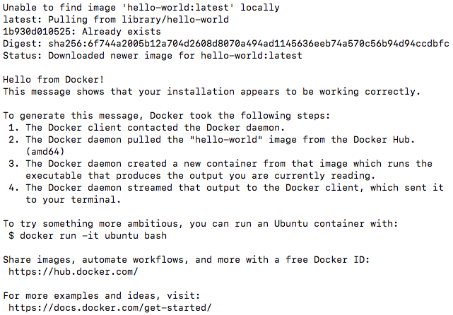

#### Descargar el contenedor de docker para la clase (programas a usar)

Preparé un contenedor de docker con los programas necesarios para las clases. Abran una terminal y corran los siguientes comandos: docker pull jrbermudez/myngs:CBG.v1

Después de la descarga les debería de aparecer la imagen del contenedor jrbermudez/myngs si corren el siguiente comando: docker images

#### Descargando los archivos para la clase (datos y scripts)

En la siguiente liga encontrarán los archivos con los que trabajaremos durante las 3 clases de transcriptómica. https://drive.google.com/open?id=11L3ahjRj8EjhrzFrwp-drqAIVh-CCKrg

Favor de descargar este directiorio (docker_workdir) y ponerlo en un lugar donde ustedes conozcan su localización. Mi recomendación sería ponerlo en el escritorio.

[figure not shown]

Ahora estás list@ para iniciar nuestras prácticas de RNA-Seq.